# Definitions

## The Principle of Compatibility (Kirchoff's Voltage Law)

Link to Original Context in: Reading_14

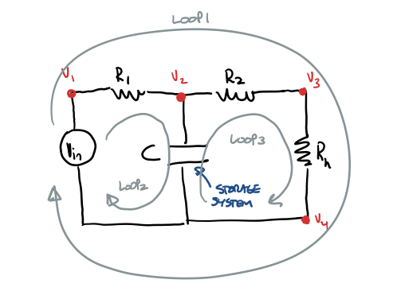

For Loop 1, the principle of compatibility states: $$\require{cancel}$$ $$ V_{41} + V_{12} + V_{23} + V_{34} = 0$$

Which, given the definition of $V_a - V_b = V_{ab}$, could be re-written as:

$$ \cancel{V}_{4} - V_1 + V_1 - V_2 + V_2 - V_3 + V_3 - \cancel{V}_{4} = 0$$

Similarly, for Loop 2, the principle of compatibility states:

$$V_{41} + V_{12} + V_{24} = 0$$

And for Loop 3, the principle of compatibility states:

$$V_{42} + V_{23} + V_{34} = 0$$

Compatibility can also be appled to fluid systems (replacing voltages with pressures) and to mechanical systems (replacing voltages with velocities).

## Power Variable Types

In all three of the types of systems we've studied, it is possible to write an equation for how work is done between elements. For example:

1. In a mechanical system, power is $F\cdot v$ for translational systems and $T\cdot \Omega$ for rotational systems
2. In an electrical system, power is $V \cdot i$
3. In a fluid system, power is $P \cdot \dot{\mathcal{V}}$.

If the first law of thermodynamics tells us that one of these two variables is conserved at a "node," we interpret this as a statement that it represents a quantity flowing "through" the node. We call this type of variable a "through type variable." In mechanical, electrical, and fluid systems, these are force, current, and flow rate, respectively.

If a variable must be measured with respect to some fixed reference in order to have meaning, and is different from one node in our model to the next, it is called an "across type variable."

For example, velocity must be measured with respect to an inertial reference frame, and varies from one end of an idealized damper to the other. Voltage must be measured with respect to some reference "ground" voltage, and varies from one end of a resistor to another. Pressure must be measured by a gauge which references some environmental (atmospheric) reference pressure, and varies from one end of a valve to the other.

Link to Original Context in: Reading_15

## Generalized Idealized Elements

All of the "idealized" system element types we have talked about thus far, by the assumptions applied to their first law equations, either store energy or transfer it to the surrounding environment. This means that all of the elements we've discussed (other than "nodes") have different amounts of power flowing into and out of them. These elements are often visualized as having two "ports," one into which power flows, and one out of which power flows. A drawing is shown below:

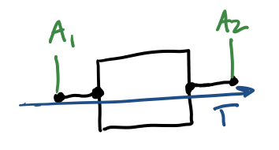

The generalized element above will have two distinct values of the A-type variable at each "end," either because the element is accumulating energy (like a mass, capacitor, or tank does), or because it is transferring energy to outside the system boundaries (like a resistor, damper, or valve).

Visualizing elements in this general way allows us to connect elements of our systems together into generalized "equivalent circuits." Doing this provides *operational efficiency* in using energy conservation (the first law) to build models for our systems.

The first law of thermodynamics for this element could be written:

$$\dot{E} = \dot{W}_{in} - \dot{W}_{out} + \dot{Q}_{in} - \dot{Q}_{out}$$

Then, recognizing that $\dot{W} = A\cdot T$, we could write the *power portion* of the first law equation as:

$$\dot{E} = A_1T - A_2T + \dot{Q}_{in} - \dot{Q}_{out}$$

note that the visualization of our generalized element **does not show** whether the element stores energy or transfers it to the element's surroundings as heat. As such this is **not** a complete energetic diagram. **We need to know what the $\dot{Q}$ terms and the $\dot{E}$ term should be for our element.** These terms are often based on similar sorts of assumptions, and yield two common types of "generalized elements."

### Energy Storage Elements

If an element *stores* energy, but does not transfer it to its surroundings, it is generally called an "energy storage element." If it stores energy via its across-type variable, it is called an "A-type storage element." Masses, rotational inertias, capacitors, and fluid capacitors are all A-type storage elements. If the element stores energy via its through-type variable, it is called a "T-type storage element." For energy storage elements, zero heat transfer to the element's surroundings is often assumed, which reduces the first law equation to:

$$\dot{E} = A_1 T - A_2 T$$

### Dissipative Elements

If an element does not *store* significant energy, but does transfer significant energy to the element's surroundings (usually via heat), we call that element a "dissipative element." Dissipative elements include electrical resistors, valves, and idealized dampers. The assumption of no energy storage for dissipative elements yields the generalized first law balance of:

$$\dot{Q}_{out} = A_1 T - A_2 T$$

### Do all physical things fall into one of these two categories?

No. It may not be reasonable to represent every physical "part" of every system as one of these two things. However, Elements that display significant energy storage *and* energy dissipative behavior can, under many circumstances, be represented by a combination of a dissipative and a storage element. We call this a "lumped element" approximation, where a "real" element is broken down into a combination of idealized storage and dissipative elements.

Link to Original Context in: Reading_15

## Generalized Equivalent Circuits

By conceptualizing each of our idealized elements as having two ports through which power flows, much like an electrical component has, we can arrange the elements into an equivalent circuit that shows us how power flows from one element to another. An example is shown below.

Link to Original Context in: Reading_15

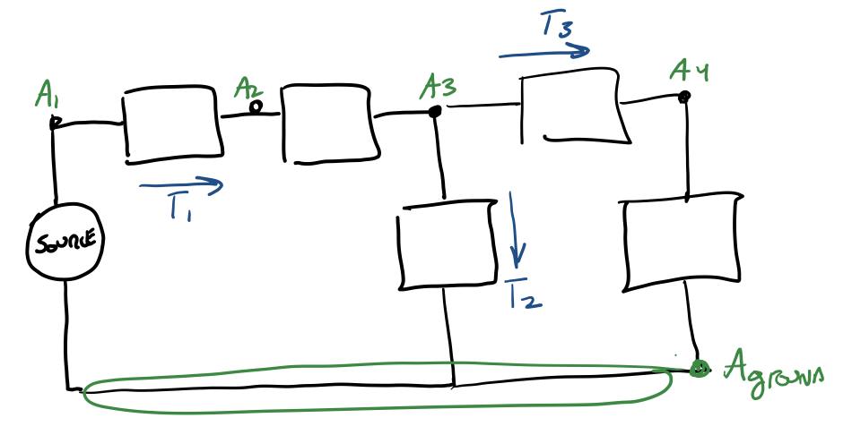

This circuit has a source (which we often model as having a defined, known value for either the T-type or A-type power variable, and thus "infinite" power potential), and 5 idealized elements. Distinct values of the across-type power variable are shown in green, and distinct values of the through-type variable are shown in blue. This circuit-like network allows us to write compatibility relations (loops relating the A type variables) and continuity relations (nodal equations for the T type variables) to aid in model construction.

Note that while this configuration allows for easy use of the first law of thermodynamics for studying how power flows from one element in our system to the others (compatibility and continuity relationships), it **does not** tell us explicitly about energy storage or dissipation for each element. Individual first law balances for each element are required, along with the construction of loop and node equations, to use the equivalent circuit for model construction.

Note that typically, the blank box used to denote each element would include the element's primary parameter. For example, a damper might be drawn as a box with a "b" in it to represent its damping coefficient. A mass might be drawn as a box with an "m" in it. A capacitor might be labeled "C."

## Disciplined Process for Model Construction with Equivalent Circuits

We already have a generic process for using the first law of thermodynamics to build a model of a dynamic system. However, the use of equivalent circuits means that we can take explicit advantage of two particular forms of the energy conservation equation: node equations (KCL) and loop equations (KVL). KCL lets us represent power transfer between elements when the T-type power variable splits and the A-type variable is constant. KVL lets us represent power transfer elements when the T-type variable is constant but the A-type variable is not.

In general, building a model of a dynamic system (one that stores significant energy, and will yield a differential equation) using an equivalent circuit can be summarized in the following steps, which should be completed **after** the model has been scoped, and before you attempt to validate your model.

1. List your independent and dependent variables.
2. Represent your system as an equivalent circuit. Draw nodes of constant A-type variable, and link them with sources and idealized two-port energy storage or energy dissipation elements. Label all distinct T-type variables as well.
3. Write the first law for each idealized element. These should reduce to "elemental" equations governing the physics of each element when common variables are canceled. Ohm's Law for an electrical resistor is an example of this.
4. Write KCL for each node in the circuit
5. Write KVL for each loop in the circuit
6. Using the node and loop equations to link power transfer between elements, reduce your set of elemental, node, and loop equations to differential equation(s) containing only independent and dependent variables.
7. Assess the internal validity of your model. Be sure that each term has the correct units, and that the sign of each term makes physical sense.

This disciplined process is simply a "streamlined" version of the one we have been using, with more explicit steps-- the efficiency advantage of writing power linkages between elements using "node" and "loop" equations is substantial, and can help you build models more quickly and with fewer algebra errors.

Link to Original Context in: Reading_15

## Idealized Power-Converting Transducers

An idealized, power-converting transducer, like all of the other physical system elements we have studied, obeys the conservation of energy. However, like the other idealized element types we've talked about, the power-converting transducer only does "one job," and that is power conversion. Therefore, if something can be said to be adequately modeled as a power-converting transducer, it cannot store energy or transfer it to the system's surroundings. In other words, its first law of thermodynamics equation in power form looks like this: $$\require{cancel}$$ $$\cancel{\dot{E}} = \dot{W}_{in} - \dot{W}_{out} + \cancel{\dot{Q}_{in}} - \cancel{\dot{Q}_{out}}$$

Simplified, we find the fundamental equation that defines an idealized power-converting transducer:

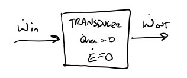

$$\dot{W}_{in} = \dot{W}_{out}$$

While this looks a bit like the equation we used to define a "node," for a transducer, $\dot{W}_{in}$ and $\dot{W}_{out}$ will always represent a change in the power variables from the "input" side to the "output" side of the element.

Link to Original Context in: Reading_16

## Representing Power-Converting Transducers in Equivalent Circuits

There is no grand universal symbol used for representing power-converting transducers in equivalent circuit diagrams. We will simply pick a symbol with the knowledge that others are possible, but all must have four "ports" in order to connect two equivalent circuits that show two different *types* of power flow.

Link to Original Context in: Reading_16

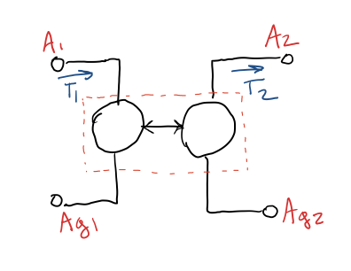

In this diagram, $A_1$ and $T_1$ represent the across and through type variables that drive the transducer ($\dot{W}_{in}$) before conversion of power, while $A_2$ and $T_2$ represent the across and through type variables generated by the transducer as it converts the input power into a different form. The double-ended arrow between the two circular "circuit elements" indicates that power is equal on each side, even though there is not a physical "wire" connecting them.

### Idealized Rotational Mechanical to Translational Mechanical Power Transducers

Wheels, Pulleys, and rack-and-pinion gears that represent contact between a translating body and a rotating body can be modeled as idealized power-converting transducers as long as there is no slip at the point of contact. Examples are shown below:

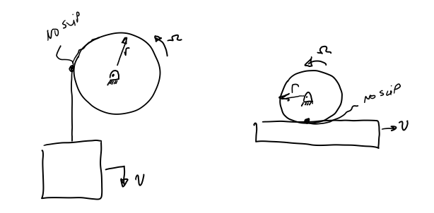

For these idealized elements, The first law of thermodynamics in power form can be written:

$$F v = T \Omega$$

and the power variables between each side of the idealized transducer can be linked by the following two equations:

$$Fr = T$$$$r\Omega = v$$

Signs may have to be adjusted given positive directions defined by the engineer. **Inertias and damping effects must be included as separate elements by the engineer**.

Link to Original Context in: Reading_16

### Idealized Electrical- Rotational Mechanical Power Transducers

If their armature (coils of wire) do not store significant magnetic field energy, DC motors and DC generators are sometimes modeled as idealized transducers with added armature resistance on the electrical side along with motor shaft inertia and viscous damping on the mechanical side. An example is shown below. The motor model's physical layout of idealized components is shown on the left, and the total equivalent circuit is shown on the right.

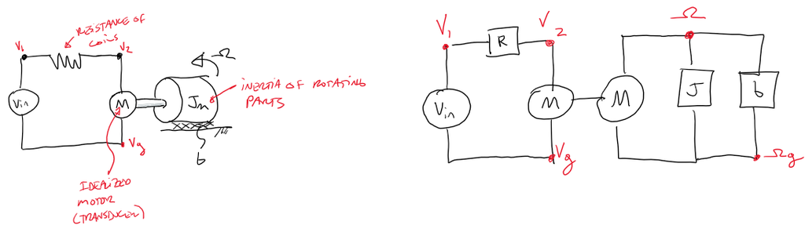

Link to Original Context in: Reading_16

The idealized transducer encompasses the motor's conversion of electrical to rotational mechanical power. Assuming no significant heat transfer or energy storage, the idealized part of the motor has a first law of thermodynamics equation that can be written:

$$V_{2g} i = T\Omega$$

With the following two equations relating torque with current and angular velocity with voltage drop:

$$T = k i $$$$V_{2g} = k \Omega$$

### Idealized Fluid- Rotational Mechanical Power Transducers

For pumps and turbines that can be modeled as idealized power transducers that convert flow work to rotational mechanical work without significant losses or energy storage, we can write the first law of thermodynamics with the assumption of no energy storage or heat transfer as:

$$P_{12}\dot{\mathcal{V}} = T \Omega $$

The physical linkage between mechanical and fluid power variables is due first to the translation between fluid pressure on the turbine/pump blade(s) and torque about the turbine/pump axis according to Newton's second law. Generally, a single empirically-derived parameter is used for this conversion:

$$T = D P_{12}$$

The other piece of the conversion has to do with how the volumetric flow rate of fluid passing through the turbine or pump is related to its angular velocity:

$$D\Omega = \dot{\mathcal{V}}$$

This coupling coefficient "D" for a pump is often conceptualized as the volume displaced per unit motion of the pump/turbine (so for a rotating pump/turbine, it would have units of $\frac{m^3}{rad}$.

Link to Original Context in: Reading_16

## Mechanical Springs

Mechanical springs come in all shapes and sizes. If the spring is *linear*, which many are (at least for small values of spring deflection), it follows *Hooke's Law*, which states that there is a linear relationship between force (for a translational spring) or torque (for a torsional spring) and the spring's deflection.

A diagram representing an "ideal" spring, which has negligible mass and dissipates negligible heat to the environment when it is deformed, is often drawn as follows. Both a torsional (rotational) spring and a translational spring are represented in the diagram below.

Link to Original Context in: Reading_18

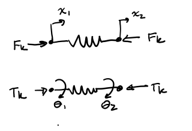

As drawn, Hooke's Law can be written for the translational spring as:

$$F_k = K(x_1-x_2) = Kx_{12}$$

If you imagine the scenario in which $x_{12}>0$, or $x_1>x_2$, it is clear that the spring would be in compression as shown. If the sign of $x_{12}$ were to flip, Hooke's Law would predict a negative force, meaning that the spring would be in tension with $F_k$ pointing outwards from each end. For a translational spring, spring constant "K" can be represented in SI units of $\frac{N}{m}$.

The expression of Hooke's Law for a torsional spring is similar:

$$T_k = K(\theta_1 - \theta_2) = K\theta_{12}$$

For a torsional spring, the spring constant $K$ can be expressed in base SI units of $\frac{Nm}{rad}$.

The picture above shows a free-body diagram on each type of spring. If a spring's mass is negligible, Newton's second law for the spring indicates that the force on each end of the spring must be an equal $F_k$ for a translational spring, and $T_k$ for a torsional spring.

From an energetic perspective, if a spring is considered massless, it ONLY stores elastic potential energy, and stores no kinetic energy. If it is also assumed that the spring does not, by itself, dissipate significant energy across the system boundaries through heat transfer, then the first law tells us that any work done on the spring will cause it to store potential energy.

$$\require{cancel}$$$$E = W_{net} + \cancel{Q_{net}}$$

Similarly, for a torsional spring, we can write: $$E = W_{net} + \cancel{Q_{net}}$$

because mechanical work is $F\cdot x$ for a translational system and $T\cdot \theta$ for a rotational system, the spring's energy storage can be expressed for a translational spring as: $$\require{cancel}$$ $$E = W_{net} + \cancel{Q_{net}} = \int F_k dx_{12} = \frac{1}{2} K x_{12}^2$$ Similarly, for a torsional spring, we can write: $$E = W_{net} + \cancel{Q_{net}} = \int F_k d\theta_{12} = \frac{1}{2} K \theta_{12}^2$$

These equations represent the stored *Elastic Potential Energy* in the spring. However, the issue with both of these forms of the energy storage equation for springs is that they don't include a *power variable*. This means that writing the first law of thermodynamics for the spring in *power* form doesn't produce a clean statement about power variables. Without a direct statement about how the spring's power variables interact, applying continuity and compatibility equations to a mechanical system with a spring would be difficult.

for this reason, the energy in a translational spring is often re-written as:

$$E = \frac{1}{2K} F_k^2$$

and for a torsional spring as:

$$E = \frac{1}{2K} T_k^2$$

A quick algebraic substitution of $F_k= K x_{12}$ for the translational spring or $T_k = K \theta_{12}$ for the torsional spring will show that the two types of expressions for stored energy are equivalent.

Th expression for stored spring energy in terms of *power variables* shows us that unlike a mass, which stores kinetic energy by accumulating the *across* type power variables $v$ or $\Omega$, a spring stores energy by accumulating the *through* type power variables $F$ or $T$. For this reason, springs are often called "Through Type" energy storage elements.

Using the power-variable form of the energy storage equation, we can write the first law of thermodynamics in power form for a translational spring as:

$$\dot{E} = \frac{1}{K} F_k \dot{F}_k = \dot{W}_{in}-\dot{W}_{out} = F_k v_{12}$$

and for a torsional spring, we find a similar relationship:

$$\dot{E} = \frac{1}{K} T_k \dot{T}_k = \dot{W}_{in}-\dot{W}_{out} = T_k \Omega_{12}$$

Cancelling the extra appearance of the through-type variables in each of these equations, we find that for a translational spring, we have:

$$\dot{F}_k = Kv_{12}$$

and for a torsional spring, we have:

$$\dot{T}_k = K\Omega_{12}$$

Where "1" and "2" represent the two "ends" of each spring. With these equations, springs are easy to include in equivalent-circuit representations of mechanical systems.

# Model Evaluation

## Model Evaluation

Link to Original Context in: Reading_01

Once a model is constructed, it must be evaluated to see how well it matches the system it is supposed to represent. This is typically done by conducting an experiment on the real system if possible, collecting data, and comparing those data to the output(s) of the model. It is important that if data were used in the *construction* phase to determine relationships between elements in the model, *new* data under different conditions are collected for the evaluation phase. This will help inform us about how well the model *generalizes*, or represents the behavior of the model under new circumstances.

## Basic Operations in the MATLAB/Octave Programming Language

Link to Original Context in: Reading_01

Octave, which is the open-source version of MATLAB, can be used as a simple calculator. Operations are performed one line at at time. See the "cell" below, which defines two variables, adds their values on one line, and then multiplies them on the next. More information about basic arithmetic operations can be found at [this link](https://www.mathworks.com/help/matlab/arithmetic-operators.html). To "run" or execute the code in this cell, select it, and then hit Shift+Enter (Hold Shift, then hold Enter as well).

```matlab
% a comment, which is not executed, is noted by a %. In Jupyter, make sure this % is followed by a space.
% use comments to tell the reader what we are doing. First, we "define" a variable a to be the number 2.
a = 2; % the semicolon at the end of the line means "don't show me this when you execute the code."
% now, we will define a second variable. Variable names should be descriptive when possible.
b = 3.02;
% now we will add them together.
c = a+b % note there is no semicolon, which means the code will "Show" us the result
d = a*b %same here. When you run this cell, think about what you expect to see!
```

```
c =  5.0200
d =  6.0400
```

Often we need "arrays" or lists of numbers in order to plot data. MATLAB can also perform arithmetic on these, as shown below.

More detailed information about accessing and manipulating arrays in MATLAB can be found [here](https://www.mathworks.com/help/matlab/math/array-indexing.html) and [here](https://www.mathworks.com/help/matlab/matlab_prog/array-vs-matrix-operations.html).

If you have trouble understanding what is happening in the cell below, I suggest you visit both of these links.

```matlab
% let's create a matrix (an array) of numbers. One column will represent time, and the other will represent "f," which we have computed as some function of time.
% arrays are defined by row. a semicolon inside the definition of the array, which begins and ends with [], means "create a new row"
data = [ 1  10; 2 11; 3 10; 4 9; 5 8] %no semicolon at the end... we should see this one when we execute.

% let's subtract 1 second from all of the times in 'data.' We can access the "times" in our data, or the first column only, as follows:
data(:,1) = data(:,1)-1 %notice that we have UPDATED all values in the first column of the array. the colon : in data(:,1) represents "all rows" in the "first column"

% Now, let's say we need to convert the units of column 2 from meters to centimeters. We could do this by multiplying all elements in the second column by 100.
data(:,2) = data(:,2)*100

%when you run this cell, you will see "Data" printed three times, with the updates we made as we made them.
```

```
data =

    1   10
    2   11
    3   10
    4    9
    5    8

data =

    0   10
    1   11
    2   10
    3    9
    4    8

data =

      0   1000
      1   1100
      2   1000
      3    900
      4    800
```

One of the major advantages of MATLAB/Octave as a language is its built-in data visualization (plotting) capability. Let's imagine that we wanted to plot "f" vs. time for the fictitious data above. We could do this using the functionality in the following cell. Note that the Jupyter notebook (this document) "stores" the values of our variables from cell to cell, so we can access "data" in the cell below to plot it. more information about plotting and line styles is available [here](https://www.tutorialspoint.com/matlab/matlab_plotting.htm).

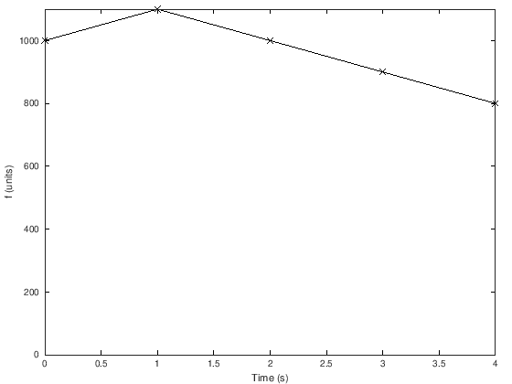

```matlab
% first, let's "pull out" time and "f" from our data matrix, so that each is a simple, nx1 (n rows by 1 column) array.
t = data(:,1); % we don't need to see it, do we? If you want to look at it, remove the semicolon.
f = data(:,2);
%now use the "figure" and plot" commands to create a new figure, and then plot x (time) vs. y (f) on a set of axes.
figure %just call this to create a new figure
plot(t,f,'k-x') %this command tells Octave to plot f vs. t in black with x at each data point and a line connecting them (color codes available at the link above)
xlabel('Time (s)') % a proper plot has x and y axes labeled!
ylabel('f (units)')
axis([0 max(t) 0 max(f)]) % this is optional, but allows us to set the scale of the plot. Format is axes([ min_x max_x min_y max_y])
```

Because we often want to make *comparisons* between predictions and data in MATLAB/Octave, we often need to plot more than one thing on one figure. This is shown below.

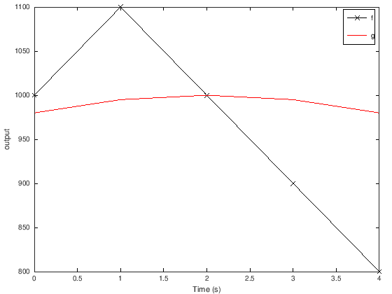

```matlab
% consider that, in addition to plotting "f" above, we want to plot "g," which is a second array of values we create using an EQUATION
% that represents g(t). We will use MATLAB to implement this function and plot its results on top of "f"
% recall that 'data' and 't' should still be defined from when we executed the cells above. If they are not, we will see a descriptive error message.

% let's define 'g' as our function of time. note that element-wise multiplication and power operations (raising each element to a power, for instance) require a period before the operator symbol.
g = -1000 * (0.005.*(t-2).^2) + 1000; % also note the parentheses here to make the order of operations very explicit.

%now plot g and f both versus time.
figure
plot(t,data(:,2),'k-x',t,g,'r')
xlabel('Time (s)')
ylabel('output')
%note the new command here, which produces a LEGEND telling us which color is which thing.
legend('f','g')
```

## Simulating Second Order Differential Equations using Euler Integration

To simulate a second order differential equation using Euler integration, consider how we thought of Euler integration in Reading 6. Computing the integral of a function was visualized as a process of repeated linear extrapolation over small timesteps.

If we consider a system model that is a *second order* differential equation that takes the form:

$$\ddot{y} = f(\dot{y},y,u)$$

where $u$ is our system's input, $y$ is our system's output, and "$f$" represents our **model** equation relating $\ddot{y}$ to $\dot{y}$ and $y$ and $u$, numerically integrating our function for $\ddot{y}$ could be used to produce an estimate of $\dot{y}$. Then, numerically integrating $\dot{y}$ one more time could be used to produce an estimate of $y$.

This process of integrating $\ddot{y}$ once, then another time, to produce our final estimate of our model's output is attractive, and could be represented by the figure below, in which $\ddot{y}(k-1)$ is used to extrapolate an estimate for $\dot{y}$, and $\dot{y}(k-1)$ is used to extrapolate an estimate for $y(k)$.

Link to Original Context in: Reading_17

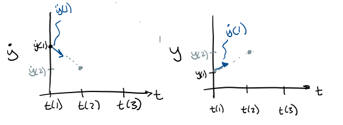

The difficulty with this approach is that $\ddot{y}$ *depends on our last estimate of $\dot{y}$, $\dot{y}(k-1)$ as well as our last estimate of $y$, $y(k-1)$ and our last input $u(k-1)$.* This means that the two integration operations have to occur in the *same* loop. The structure of such a loop can be summarized as follows, where `yd` represents $\dot{y}$ and `ydd` represents $\ddot{y}$:

```
for k=2:length(t)
    % compute second derivative of output based on model equation, represented here by "f."
    ydd(k-1) = f(yd(k-1),y(k-1),u(k-1));
    % now extrapolate once to get our new estimate of the first derivative of y
    yd(k) = yd(k-1) + (t(k)-t(k-1))*ydd(k-1);
    % now extrapolate a second time to get our new estimate of y itself.
    y(k) = y(k-1) + (t(k)-t(k-1))*yd(k-1);
end
```

Notice that we are are not using the *new* estimate of $\dot{y}$ in the second integration! See the figure above to see why-- we are calculating the slope of each function one timestep behind where we would like to predict *to*.

Also note that for this approach to work, an initial condition for $y$ is needed along with an initial condition for $\dot{y}$ so that the values `y(1)` and `yd(1)` are known, and can be used as the starting point for extrapolation on the first iteration of the loop.